# exoplanet_predictor

## Pardon the interruption...

#### pycaret

```python
from pycaret.classification import setup
from pycaret.classification import compare_models, plot_model, evaluate_model, interpret_model
# setup the dataset

grid = setup(data=df_cleaned, target='koi_disposition', html=False, silent=True, verbose=False)
# evaluate models and compare models
best = compare_models()
# report the best model
print(best)
```

[output not shown]

[output not shown]

[output not shown]

[output not shown]

[output not shown]

[output not shown]

[output not shown]

[output not shown]

[output not shown]

[output not shown]

[output not shown]

[output not shown]

[output not shown]

|  | Model | Accuracy | AUC | Recall | Prec. | F1 | Kappa | MCC | TT (Sec) |
| --- | --- | --- | --- | --- | --- | --- | --- | --- | --- |
| lightgbm | Light Gradient Boosting Machine | 0.8587 | 0.9645 | 0.8313 | 0.8557 | 0.8560 | 0.7726 | 0.7737 | 0.308 |
| gbc | Gradient Boosting Classifier | 0.8543 | 0.9627 | 0.8254 | 0.8512 | 0.8514 | 0.7653 | 0.7666 | 2.965 |
| rf | Random Forest Classifier | 0.8521 | 0.9610 | 0.8204 | 0.8481 | 0.8486 | 0.7611 | 0.7625 | 0.256 |
| et | Extra Trees Classifier | 0.8433 | 0.9574 | 0.8118 | 0.8398 | 0.8406 | 0.7480 | 0.7489 | 0.114 |
| ada | Ada Boost Classifier | 0.8154 | 0.9148 | 0.7825 | 0.8107 | 0.8115 | 0.7034 | 0.7047 | 0.197 |
| dt | Decision Tree Classifier | 0.7980 | 0.8478 | 0.7665 | 0.7996 | 0.7985 | 0.6772 | 0.6775 | 0.058 |
| lda | Linear Discriminant Analysis | 0.7889 | 0.9326 | 0.7503 | 0.7881 | 0.7872 | 0.6634 | 0.6646 | 0.022 |
| knn | K Neighbors Classifier | 0.6108 | 0.7783 | 0.5832 | 0.6223 | 0.6147 | 0.3888 | 0.3901 | 0.027 |
| svm | SVM - Linear Kernel | 0.3253 | 0.0000 | 0.3333 | 0.1188 | 0.1702 | 0.0000 | 0.0000 | 0.096 |
| lr | Logistic Regression | 0.2499 | 0.5000 | 0.3333 | 0.0625 | 0.0999 | 0.0000 | 0.0000 | 0.130 |
| nb | Naive Bayes | 0.2499 | 0.0000 | 0.3333 | 0.0625 | 0.0999 | 0.0000 | 0.0000 | 0.015 |
| qda | Quadratic Discriminant Analysis | 0.2499 | 0.0000 | 0.3333 | 0.0625 | 0.0999 | 0.0000 | 0.0000 | 0.017 |
| ridge | Ridge Classifier | 0.0000 | 0.0000 | 0.0000 | 0.0000 | 0.0000 | 0.0000 | 0.0000 | 0.013 |

```
LGBMClassifier(boosting_type='gbdt', class_weight=None, colsample_bytree=1.0,
               importance_type='split', learning_rate=0.1, max_depth=-1,
               min_child_samples=20, min_child_weight=0.001, min_split_gain=0.0,
               n_estimators=100, n_jobs=-1, num_leaves=31, objective=None,
               random_state=314, reg_alpha=0.0, reg_lambda=0.0, silent=True,
               subsample=1.0, subsample_for_bin=200000, subsample_freq=0)
```

```python
# tune model hyperparameters on the sonar classification dataset
# from sklearn.ensemble import XGBClassifier
from lightgbm import LGBMClassifier
from pycaret.classification import setup
from pycaret.classification import tune_model

# grid = setup(data=train_features, target=train_labels, html=False, silent=True, verbose=False)
# tune model hyperparameters
best = tune_model(LGBMClassifier(), n_iter=200, choose_better=True)
# report the best model
print(best)
```

```
Fitting 10 folds for each of 200 candidates, totalling 2000 fits
```

[output not shown]

|  | Accuracy | AUC | Recall | Prec. | F1 | Kappa | MCC |
| --- | --- | --- | --- | --- | --- | --- | --- |
| 0 | 0.8642 | 0.9698 | 0.8372 | 0.8617 | 0.8623 | 0.7823 | 0.7829 |
| 1 | 0.8761 | 0.9700 | 0.8501 | 0.8730 | 0.8739 | 0.8003 | 0.8010 |
| 2 | 0.8627 | 0.9667 | 0.8362 | 0.8590 | 0.8599 | 0.7785 | 0.7794 |
| 3 | 0.8448 | 0.9582 | 0.8177 | 0.8432 | 0.8435 | 0.7518 | 0.7522 |
| 4 | 0.8670 | 0.9631 | 0.8346 | 0.8633 | 0.8625 | 0.7839 | 0.7864 |
| 5 | 0.8640 | 0.9665 | 0.8336 | 0.8602 | 0.8601 | 0.7801 | 0.7819 |
| 6 | 0.8550 | 0.9656 | 0.8286 | 0.8538 | 0.8532 | 0.7684 | 0.7694 |
| 7 | 0.8879 | 0.9738 | 0.8694 | 0.8855 | 0.8859 | 0.8194 | 0.8202 |
| 8 | 0.8356 | 0.9557 | 0.8037 | 0.8325 | 0.8337 | 0.7350 | 0.7354 |
| 9 | 0.8520 | 0.9659 | 0.8335 | 0.8512 | 0.8515 | 0.7636 | 0.7637 |
| Mean | 0.8609 | 0.9655 | 0.8345 | 0.8584 | 0.8586 | 0.7763 | 0.7773 |
| SD | 0.0143 | 0.0051 | 0.0165 | 0.0140 | 0.0139 | 0.0225 | 0.0227 |

```
LGBMClassifier(bagging_fraction=0.9, bagging_freq=5, boosting_type='gbdt',
               class_weight=None, colsample_bytree=1.0, feature_fraction=0.8,
               importance_type='split', learning_rate=0.15, max_depth=-1,
               min_child_samples=26, min_child_weight=0.001, min_split_gain=0.8,
               n_estimators=260, n_jobs=-1, num_leaves=90, objective=None,
               random_state=None, reg_alpha=0.4, reg_lambda=0.3, silent=True,
               subsample=1.0, subsample_for_bin=200000, subsample_freq=0)
```

#### train baseline model

```
Finished loading model, total used 64 iterations
```

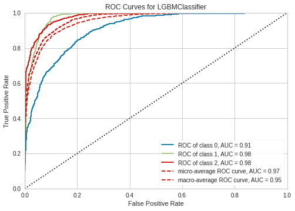

```python
plot_model(best)
```

```
Finished loading model, total used 64 iterations
```

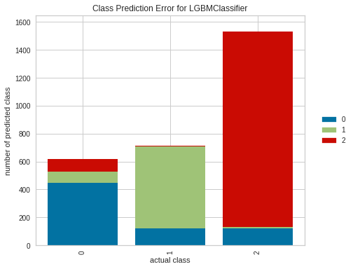

```python
plot_model(best,plot = 'error')
```

```
Finished loading model, total used 64 iterations
```

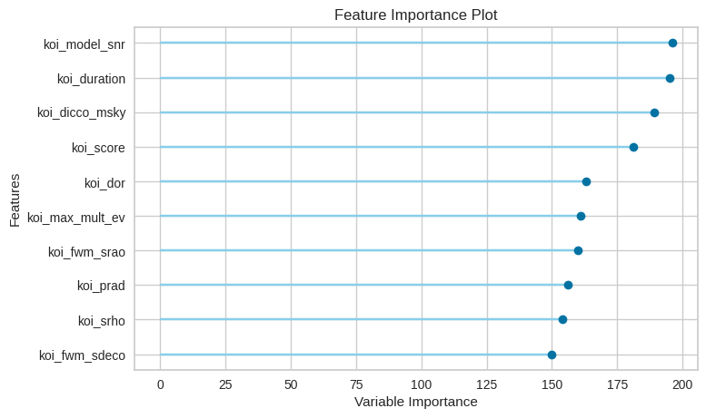

```python
plot_model(best,plot = 'feature')
```

```python
evaluate_model(best)
```

```
Finished loading model, total used 64 iterations
```

|  | Parameters |
| --- | --- |
| boosting_type | gbdt |
| class_weight | None |
| colsample_bytree | 1.0 |
| importance_type | split |
| learning_rate | 0.15 |
| max_depth | -1 |
| min_child_samples | 26 |
| min_child_weight | 0.001 |
| min_split_gain | 0.8 |
| n_estimators | 260 |
| n_jobs | -1 |
| num_leaves | 90 |
| objective | None |
| random_state | None |
| reg_alpha | 0.4 |
| reg_lambda | 0.3 |
| silent | True |
| subsample | 1.0 |
| subsample_for_bin | 200000 |
| subsample_freq | 0 |
| feature_fraction | 0.8 |
| bagging_freq | 5 |
| bagging_fraction | 0.9 |

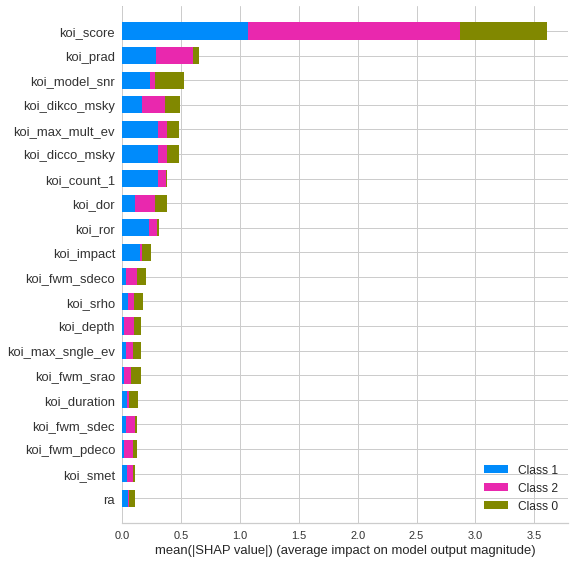

```python
interpret_model(best)
```

### AutoML

```python
automl_model = automl(optimize = 'MAE')
pred_holdouts = predict_model(automl_model)
pred_holdouts.head()
```

```python
new_data = features.copy()
new_data.drop(['koi_disposition'], axis=1, inplace=True)
predictions = predict_model(automl_model, data=new_data)
predictions.head()
```

```python
!mlflow ui
```

```python
from pycaret.regression import *
reg_experiment = setup(data=df_final,
                      target='koi_disposition',
                      log_experiment=True,
                      experiment_name='exoplanets')
```

```python
best_model = compare_models(fold=5)
```

```python
# Instantiate model with 1000 decision trees
rf = RandomForestClassifier(n_estimators = 1000, random_state = 42)
rf.fit(train_features, train_labels)
```

```python
predictions = rf.predict(test_features)
print("Accuracy score: ", accuracy_score(test_labels, predictions))
print("Recall score: ", recall_score(test_labels, predictions, average=None))
cv_score = cross_val_score(rf, train_features, train_labels, cv=3, scoring='accuracy')
print("Cross validation score: ", cv_score)
print(classification_report(test_labels,predictions))
```

#### confusion matrix

```python
train_pred = cross_val_predict(rf, train_features,train_labels, cv=3)
conf_matrix_rf = pd.DataFrame(confusion_matrix(train_labels,
                                               train_pred,
                                               labels=['CANDIDATE','CONFIRMED','FALSE POSITIVE']),
                              index = ['Actual Candidate', 'Actual Confirmed', 'Actual FP'],
                              columns = ['Predicted Candidate', 'Predicted Confirmed', 'Predicted FP']
                             )
print(conf_matrix_rf)
plot_cm(conf_matrix_rf)
```

#### randomized search

```python
# Number of trees in random forest
n_estimators = [int(x) for x in np.linspace(start = 100, stop = 2000, num = 10)]
# Number of features to consider at every split
max_features = ['auto', 'sqrt']
# Maximum number of levels in tree
max_depth = [int(x) for x in np.linspace(10, 110, num = 11)]
max_depth.append(None)
# Minimum number of samples required to split a node
min_samples_split = [2, 5, 10]
# Minimum number of samples required at each leaf node
min_samples_leaf = [1, 2, 4]
# Method of selecting samples for training each tree
bootstrap = [True, False]

# Create the random grid
random_grid = {'n_estimators': n_estimators,
               'max_features': max_features,
               'max_depth': max_depth,
               'min_samples_split': min_samples_split,
               'min_samples_leaf': min_samples_leaf,
               'bootstrap': bootstrap}

rf_2 = RandomForestClassifier(random_state = 42)
```

Random search of parameters, using 3 fold cross validation, search across 100 different combinations, and use all available cores

```python
rf_random = RandomizedSearchCV(estimator = rf_2,
                               param_distributions = random_grid,
                               n_iter = 100,
                               cv = 3,
                               verbose=2,
                               random_state=42,
                               n_jobs = -1)
# Fit the random search model
rf_random.fit(train_features, train_labels)
```

```python
# %% best params - use these params for the next model
print(rf_random.best_params_)
```

#### Model with Random Search CV Params

```python
rf_rs = RandomForestClassifier(n_estimators = 311,
                               min_samples_split = 5,
                               min_samples_leaf = 1,
                               max_features = 'auto',
                               max_depth = 90,
                               bootstrap = False)
```

```python
rf_rs.fit(train_features, train_labels)
```

```python
print(rf_rs.score(train_features, train_labels))
y_pred = rf_rs.predict(test_features)
print(accuracy_score(test_labels, y_pred))
print(classification_report(test_labels, y_pred))
```

```python
# confusion matrix & accuracy
rs_pred = cross_val_predict(rf_rs, test_features,test_labels, cv=3)
conf_matrix_rf = confusion_matrix(test_labels, rs_pred)
conf_matrix_rf = pd.DataFrame(confusion_matrix(test_labels,
                                               rs_pred,
                                               labels=['CANDIDATE','CONFIRMED','FALSE POSITIVE']),
                              index = ['Actual Candidate', 'Actual Confirmed', 'Actual FP'],
                              columns = ['Predicted Candidate', 'Predicted Confirmed', 'Predicted FP']
                             )
print(conf_matrix_rf)
plot_cm(conf_matrix_rf)
```

```python
print("Accuracy score: ", accuracy_score(test_labels, rs_pred))
print("Recall score: ", recall_score(test_labels, rs_pred, average=None))
print("Precision score: ", precision_score(test_labels, rs_pred, average=None))
```

TPOT is an open-source library for performing AutoML in Python. It makes use of the popular Scikit-Learn machine learning library for data transforms and machine learning algorithms and uses a Genetic Programming stochastic global search procedure to efficiently discover a top-performing model pipeline for a given dataset. [1](https://machinelearningmastery.com/tpot-for-automated-machine-learning-in-python/)

```python
# TPOT

# Number of trees in random forest
n_estimators = [int(x) for x in np.linspace(start = 200, stop = 2000, num = 10)]
# Number of features to consider at every split
max_features = ['auto', 'sqrt','log2']
# Maximum number of levels in tree
max_depth = [int(x) for x in np.linspace(10, 1000,10)]
# Minimum number of samples required to split a node
min_samples_split = [2, 5, 10,14]
# Minimum number of samples required at each leaf node
min_samples_leaf = [1, 2, 4,6,8]
# Create the random grid
param = {'n_estimators': n_estimators,
               'max_features': max_features,
               'max_depth': max_depth,
               'min_samples_split': min_samples_split,
               'min_samples_leaf': min_samples_leaf,
              'criterion':['entropy','gini']}
```

```python
tpot_classifier = TPOTClassifier(generations= 5,
                                 population_size= 24,
                                 offspring_size= 12,
                                 verbosity= 2,
                                 early_stop= 12,
                                 config_dict={'sklearn.ensemble.RandomForestClassifier': param},
                                 cv = 4,
                                 scoring = 'accuracy')
tpot_classifier.fit(train_features, train_labels)
accuracy = tpot_classifier.score(test_features, test_labels)
print(accuracy)
```